# The Labyrinth of Multiple Testing: how to avoid the pitfall of false positives

The Labyrinth of Multiple Testing: how to avoid the pitfall of false positives FWER control Livio Finos and Angela Andreella

Suppose these are the p-values obtained from your last experiment:

```r
set.seed(13)
m=15
(p.values=runif(m))
```

```
##  [1] 0.71032245 0.24613730 0.38963444 0.09138367 0.96206454 0.01093333
##  [7] 0.57429518 0.76439799 0.87338231 0.04106335 0.66112160 0.87837085
## [13] 0.89055903 0.56628047 0.59354734
```

How many rejections?

```r
alpha = 0.05
(p.values < alpha)
```

```
##  [1] FALSE FALSE FALSE FALSE FALSE  TRUE FALSE FALSE FALSE  TRUE FALSE FALSE
## [13] FALSE FALSE FALSE
```

```r
sum(p.values < alpha)
```

```
## [1] 2
```

# 1 Familywise Error Rate

In hypothesis testing, the probability of committing a Type I error is controlled at a set level $\alpha$, conventionally $5\%$. However, a problem arises when we conduct not just one test, but more than one. Since for each test we have a probability of committing a type I error, if we conduct many tests it is likely to get at least one type I error.

The multiple testing problem has a simple structure.

We have a set of null hypotheses $\mathcal{H}=(H_1,\ldots,H_m)$, of which an unknown number $m_0$ are true, while the remaining $m-m_0$ are false.

We denote the subset of true hypotheses by $\mathcal{T}\subseteq \mathcal{H}$, the subset of false hypotheses by $\mathcal{F}=\mathcal{H}\setminus \mathcal{T}$ and the proportion of true hypotheses with $\pi_0=m_0/m$.

The goal of multiple testing procedures is to choose a subset $\mathcal{R}\subseteq \mathcal{H}$ of hypotheses to reject. Suppose we have available the p-values $p_1,\ldots,p_m$ for each hypothesis $H_1,\ldots,H_m$. We can consider the following procedure:

$$\mathcal{R}=\{H_i: p_i \leq
\tilde{\alpha}\}$$

that is, reject all hypotheses whose p-values are less than some threshold $\tilde{\alpha}$. The problem now is to determine this threshold $\tilde{\alpha}$.

Ideally, the set of rejected hypotheses $\mathcal{R}$ should coincide as closely as possible with the set of false hypotheses $\mathcal{F}$. Two types of errors can be made:

- type I errors $\mathcal{R}\cap \mathcal{T}$, that is, rejecting true hypotheses,
- type II errors $\mathcal{R}\setminus \mathcal{F}$, that is, not rejecting false hypotheses.

We can summarize the number of errors made in the following table:

| Assumptions | False | True | Total |
| --- | --- | --- | --- |
| rejected | $S$ | $V$ | $R$ |
| not rejected | $T$ | $U$ | $m-R$ |
| total | $m_1$ | $m_0$ | $m$ |

We know the total number of hypotheses $m$ and the number of rejected hypotheses $R=\#\mathcal{R}$, but all other table quantities are unknown.

Methods of *multiple testing* try to reject as many hypotheses as possible while trying to control the number $V$ of type I errors.

The *familywise error rate* is defined as.
$$\mathrm{FWER}=\Pr(V > 0)$$
that is, the probability of committing at least one type I error. Using the procedure reject $H_i$ if $p_i \leq \tilde{\alpha}$

we get
$$\mathrm{FWER}= \Pr\left(\bigcup_{i: H_i \in \mathcal{T}} \{ P_i \leq
\tilde{\alpha} \}\right)$$

Controlling the *familywise error rate* at a $\alpha$ level requires that
$$\mathrm{FWER}\leq \alpha.$$

## 1.1 Sidak’s inequality: independent P-values.

In our example, we are in the following situation:

- the $m=$ 15 hypotheses are all true, i.e. $m_0=m$;
- the 15 tests, and thus the related p-values, are independent of each other;
- without regard to the multiplicity of the tests, we reject $H_i$ when $p_i \leq \alpha$.

We denote by $E_i=I\{P_i \leq \alpha\}$ the outcome of the test, i.e., through the indicator function which is 1 if we reject the hypothesis, 0 otherwise.

Since the hypotheses are all true, the p-values $P_1,\ldots,P_m$ are i.i.d. $\mathrm{Uniform}(0,1)$. It follows that $E_i \sim \mathrm{Bernoulli}(\alpha)$ and $V = \sum_{i=1}^{m}E_i \sim \mathrm{Binomial}(n,\alpha)$. Then the familywise error rate results in.
$$\mathrm{FWER}= \Pr(V > 0) = \Pr(\sum_{i=1}^{m}E_i > 0) = 1 -
\Pr(\sum_{i=1}^{m}E_i = 0) = 1 - (1-\alpha)^m$$
or equivalently
$$\mathrm{FWER}= \Pr\left(\bigcup_{i=1}^{m} \{ P_i \leq \alpha \} \right)
= 1- \Pr\left(\bigcap_{i=1}^{m} \{ P_i > \alpha \right) = 1-
\prod_{i=1}^{m} \Pr\left( P_i > \alpha \right) =1 - (1-\alpha)^m$$

that is, for $m=$ 15

```r
1 - (1-alpha)^(m)
```

```
## [1] 0.5367088
```

Let us try to represent the *familywise error rate* as a function of the number of the number of hypotheses $m$ (again assuming $m_0=m$)

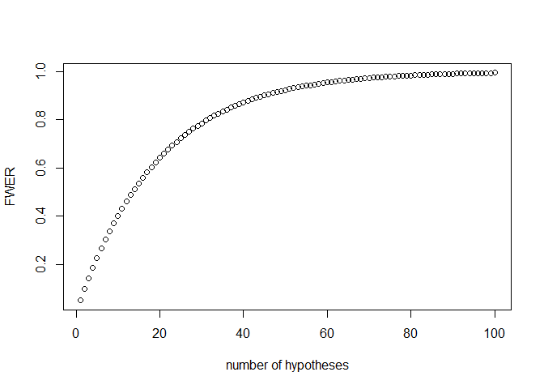

```r
# m = 100
FWER<- 1-(1-alpha)^(1:100)
plot(1:100,FWER,xlab="number of hypotheses", ylab="FWER")
```

To control FWER at a $\alpha$ level, we need to modify our rejection rule:

- we reject $H_i$ when $p_i \leq \tilde{\alpha}$.

Solving $\mathrm{FWER}= 1 - (1-\tilde{\alpha})^m = \alpha$ we get
$$\tilde{\alpha} = 1-(1-\alpha)^{(1/m)}$$
or

```r
alpha.adj<-1 - (1-alpha)^(1/m)
alpha.adj
```

```
## [1] 0.003413713
```

```r
(p.values < alpha.adj)
```

```
##  [1] FALSE FALSE FALSE FALSE FALSE FALSE FALSE FALSE FALSE FALSE FALSE FALSE
## [13] FALSE FALSE FALSE
```

Equivalently, we can consider the rejection rule:

- we reject the hypothesis $H_i$ when $\tilde{p}_{i} \leq \alpha$

where
$$\tilde{p}_i = 1- (1- p_i)^{m}$$
or

```r
p.values.adj<-1- (1- p.values)^m
p.values.adj
```

```
##  [1] 1.0000000 0.9855661 0.9993921 0.7624757 1.0000000 0.1520241 0.9999973
##  [8] 1.0000000 1.0000000 0.4668508 0.9999999 1.0000000 1.0000000 0.9999964
## [15] 0.9999986
```

More generally, if Sidak’s inequality holds:
$$\Pr\left(\bigcap_{i:H_i \in \mathcal{T}} \{ P_i > u \right) \geq
\prod_{i: H_i \in \mathcal{T}} \Pr\left( P_i > u \right)$$
for each $u\in[0,1]$ and each $\mathcal{T}\subseteq \mathcal{H}$, we can use $\tilde{\alpha} = 1-(1-\alpha)^{(1/m)}$ and obtain
$$\Pr\left(\bigcap_{i: H_i \in \mathcal{T}} \{ P_i >
1-(1-\alpha)^{(1/m)} \} \right) \geq \prod_{i: H_i\in \mathcal{T}}
\Pr\left( P_i > 1-(1-\alpha)^{(1/m)} \right) =
[(1-\alpha)^{(1/m)}]^{m_0} = (1-\alpha)^{\pi_0} \geq 1-\alpha$$
And then check the FWER at $\alpha$:
$$\mathrm{FWER} = \Pr\left(\bigcup_{i: H_i \in \mathcal{T}} \{ P_i <
1-(1-\alpha)^{(1/m)} \} \right) = 1- \Pr\left(\bigcap_{i: H_i \in
\mathcal{T}} \{ P_i > 1-(1-\alpha)^{(1/m)} \} \right) \leq \alpha$$

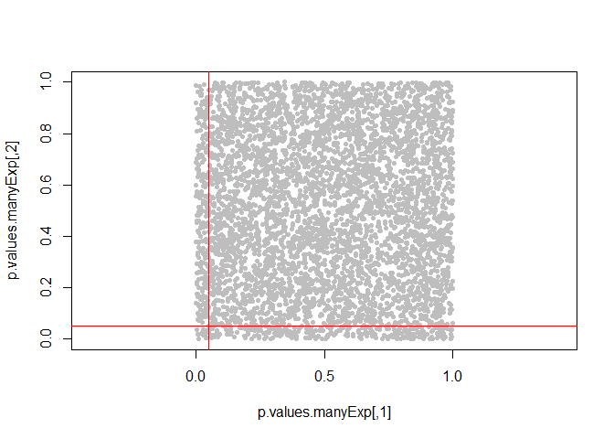

```r
p.values.manyExp=cbind(runif(5000),runif(5000))
plot(p.values.manyExp,pch=20,col="grey",asp=1)
abline(v=.05,col="red")
abline(h=.05,col="red")
```

Let’s try to run a simulation to verify that the FWER is really controlled at $\alpha$

```r
B<-5000
V<-vector("numeric", length=B)
for (i in 1:B){
U<-runif(m)
V[i]<-sum(U <= alpha.adj)
}
mean(V>0)
```

```
## [1] 0.0482
```

# 2 Bonferroni inequality

## 2.1 Dependence between tests.

Variables in an experiment are often correlated with each other.

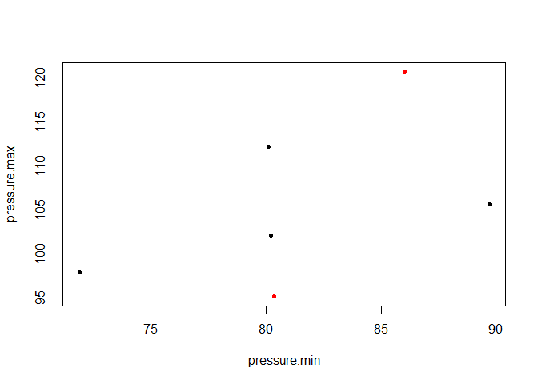

```r
effect.individual=rnorm(6,mean = 0,sd = sqrt(70))
pressure.min=rnorm(6,mean = 82,sd = sqrt(30))+effect.individual
pressure.max=rnorm(6,mean = 105,sd = sqrt(30))+effect.individual

plot(pressure.min,pressure.max,col=c("black", "black", "black", "red", "red"),pch=20)
```

```r
cor(pressure.min,pressure.max)
```

```
## [1] 0.5195374
```

```r
data=data.frame(drug=c("standard", "standard", "standard",
                        "new", "new", "new"),
                pressure.min=pressure.min,
                pressure.max=pressure.max)
data
```

| drug | pressure.min | pressure.max |
| --- | --- | --- |
| standard | 80.21564 | 102.04702 |
| standard | 71.88510 | 97.84951 |
| standard | 80.11237 | 112.11309 |
| new | 86.00768 | 120.66366 |
| new | 80.33573 | 95.10682 |
| new | 89.69549 | 105.60302 |

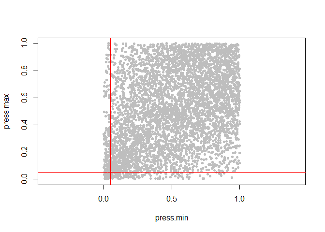

```r
B=5000
res=replicate(B,{
  effect.individual=rnorm(6,mean = 0,sd = sqrt(70))
  pressure.min=rnorm(6,mean = 82,sd = sqrt(30))+effect.individual
  pressure.max=rnorm(6,mean = 105,sd = sqrt(30))+effect.individual
  c(press.min=t.test(pressure.min[1:3],pressure.min[4:6])$p.value,
    press.max=t.test(pressure.max[1:3],pressure.max[4:6])$p.value)
})
res=t(res)
plot(res,pch=20,col="grey",asp=1)
abline(v=.05,col="red")
abline(h=.05,col="red")
```

```r
#with what probability both p-values<.05? (lower left area)
sum((res[,1]<.05)&(res[,2]<.05))/B
```

```
## [1] 0.0074
```

```r
# how much is expected in case of test independence?
.05*.05
```

```
## [1] 0.0025
```

## 2.2 Bonferroni procedure

Carlo Emilio Bonferroni was an Italian mathematician, best known for the inequalities that takes his name.

[figure not shown]

Bonferroni’s inequality, also known as Boole’s inequality, states that for any finite or countable collection of events, the probability of at least one of the events happening is less than or equal to the sum of the probabilities of the individual events, i.e.

$$\Pr\left(\bigcup_{i: H_i \in \mathcal{T}} E_i \right) \leq \sum_{i: H_i
\in \mathcal{T}} \Pr\left( E_i \right)$$

so considering $E_i = \{p_i \leq \frac{\alpha}{m} \}$ we get

$$\mathrm{FWER} = \Pr\left(\bigcup_{i: H_i \in \mathcal{T}} p_i \leq
\frac{ \alpha}{m} \right) \leq \sum_{i: H_i \in \mathcal{T}} \Pr\left(
p_i \leq \frac{ \alpha}{m} \right) \leq m_0 \frac{ \alpha}{m} =
\pi_0\alpha \leq \alpha$$

that is, Bonferroni’s method controls the FWER at $\alpha$.

Bonferroni’s procedure is as follows:

- We reject $H_i$ if $p_i \leq \tilde{\alpha} = \frac{\alpha}{m}$

or equivalently.

- It rejects $H_i$ if $\tilde{p}_i = \min(mp_i,1) \leq \alpha$

## 2.3 Example: Multiple Endpoints Data

Let consider the `mtept` dataset: Measurements on four endpoints in patients in treatment (`Drug` in red) and not (`Placebo` in grey).

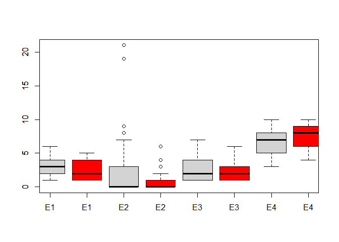

```r
require("multcomp")
data(mtept)
group<-mtept[,"treatment"]
resp<-mtept[,-1]
boxplot(resp[group=="Placebo",], at=c(1,3,5,7), xlim=c(1,8))
boxplot(resp[group=="Drug",], at=c(2,4,6,8), col="red", add=T)
```

We conduct 4 Wilcoxon tests, one for each endpoint:

```r
require("multcomp")
m<-4
p.values<-vector("numeric", length=m)
names(p.values)<-names(resp)
for (i in 1:m){
p.values[i]<-wilcox.test(resp[group=="Placebo",i], resp[group=="Drug",i])$p.value
}
p.values
```

```
##        E1        E2        E3        E4
## 0.0187036 0.2500896 0.3237945 0.0257959
```

We now adjust the vector of p-values by Bonferroni’s method:

```r
p.values.adj<-pmin(p.values*m,1)
p.values.adj
```

```
##         E1         E2         E3         E4
## 0.07481439 1.00000000 1.00000000 0.10318359
```

```r
p.adjust(p.values,method="bonferroni")
```

```
##         E1         E2         E3         E4
## 0.07481439 1.00000000 1.00000000 0.10318359
```

```r
alpha = 0.1
names(p.values.adj)[p.values.adj<=alpha] #names of the significant endpoints at alpha=10%
```

```
## [1] "E1"
```

so the comparison between `Placebo` and `Drug` groups is significant at the $\alpha=10\%$ level for endpoint `E1`.

## 2.4 Example: Golub data

Let us now consider *microarray* type data used in the study described by Golub et al. (1999). In this study, gene expression on $3051$ genes was measured for each patient. The $38$ patients considered are leukemia patients, and can be divided into two groups: $27$ patients with *acute lymphoblastic leukemia* (ALL, code `0`) and with $11$ *acute myeloid leukemia* (AML, code `1`). The aim of the study is to determine which genes are differentially expressed between the two groups of patients.

```r
if (!require("BiocManager", quietly = TRUE))
    install.packages("BiocManager")
#BiocManager::install("multtest")

library(multtest)
set.seed(123)
data(golub)
rownames(golub)<-golub.gnames[,3]
m<-500
genes<-1:m # subset of genes
response<-golub[genes,]
group<-golub.cl
p.values<-vector("numeric", length=m)
names(p.values)<-rownames(response)
for (i in 1:m){
p.values[i]<-t.test(response[i,group==0],
                    response[i,group==1])$p.value
}
sum(p.values<=alpha) # number of rejections without multiplicity corrections
```

```
## [1] 221
```

```r
sum(p.adjust(p.values,"bonferroni") <=alpha) # number of rejections wih Bonferroni correction
```

```
## [1] 25
```

```r
p.values.adj <- p.adjust(p.values,"bonferroni")
genes.sig<-names(p.values.adj)[(p.values.adj <=alpha)] # names of significant genes
genes.sig
```

```
##  [1] "AB000449_at"      "D00763_at"        "D10495_at"        "D14658_at"
##  [5] "D14874_at"        "D21262_at"        "D38524_at"        "D42043_at"
##  [9] "D43948_at"        "D63391_at"        "D63476_at"        "D63880_at"
## [13] "D84276_at"        "D86479_at"        "D86967_at"        "D87078_at"
## [17] "D87446_at"        "D87969_at"        "D88270_at"        "D88422_at"
## [21] "HG1612-HT1612_at" "HG1879-HT1919_at" "HG2855-HT2995_at" "HG4582-HT4987_at"
## [25] "J03798_at"
```

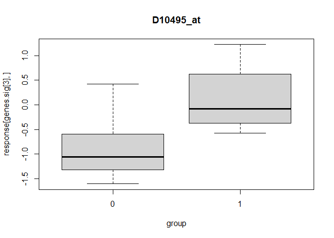

```r
boxplot(response[genes.sig[3],]~group, main=genes.sig[3]) # boxplot of the third significant genes
```

Graphically we have:

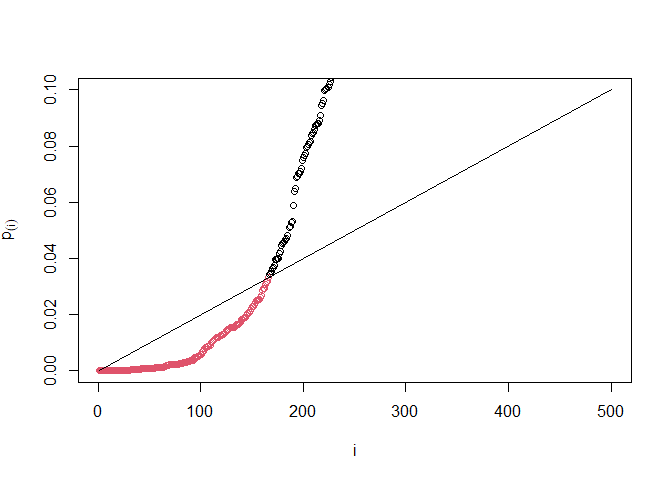

```r
i<-(sort(p.values) <= alpha*(1:m)/m)
plot(1:m, sort(p.values), xlab="i", ylab=expression(p[(i)]), col=i+1, ylim=c(0,.1))
segments(x0=1,y0=alpha/m, x1=m,y1=alpha)
```

# 3 Holm procedure

It leads to the same rejections as Bonferroni, sometimes a few more (uniformly more powerful).

It is iterative:

1. Correct the p-values with Bonferroni,
2. Reject all hypotheses with significant p-values
3. Reiterate 1. and 2. until there are no more rejections

```r
sum(p.adjust(p.values,method = "bonferroni") < 0.05)/length(p.values)
```

```
## [1] 0.044
```

```r
sum(p.adjust(p.values,method = "holm") < 0.05)/length(p.values)
```

```
## [1] 0.044
```

# Exercise 1

Let be

```
## 0.523 0.0011 0.0246 0.0073
```

the p-values resulting in the comparison of two groups in a clinical trial with four endpoints.

Perfom:

- a Bonferroni correction
- a Holm correction
- a closed testing correction using Bonferroni combination for the combined tests
- at least for the Bonferroni and Holm, program a function to perform it for a general vector of p-values

Compare the results of Closed Testing with the ones of Bonferroni and Holm.

**Possible solution**

```r
bonferroni <- function(pv){
  pmin(pv*length(pv),1)
}
```

```r
holm <- function(pv){

  pv_sort <- sort(pv)

  sapply(c(1:length(pv)), function(x) pv_sort[x] * (length(pv_sort)+ 1 - x))[order(order(pv))]
}
```

# Exercise 2: Gatekeeping procedure

Consider a clinical trial with two families of null hypotheses:

Family 1: Primary null hypotheses (one-sided p-values) $H_1$ (Endpoint 1), $p_1=0.0082$ $H_2$ (Endpoint 2), $p_2=0.0174$

Family 2: Secondary null hypotheses (one-sided p-values) $H_3$ (Endpoint 3), $p_3=0.0042$ $H_4$ (Endpoint 4), $p_4=0.0180$

where $p_i$ are the raw p-values.

- Apply the serial gatekeeping procedure
- Apply the parallel gatekeeping procedure

**Possible solution**

```r
pvalues <- c(0.0082, 0.0174, 0.0042, 0.0180)
```

```r
serial <- function(pvalues, alpha){
  if(pvalues[1] < alpha & pvalues[2] < alpha){


    data.frame(Family = rep(c(1,2), each = 2),
               Hyp = c(1:4),
               Pvalues = c(pvalues[1:2],p.adjust(pvalues[c(3,4)], method = "holm")
))

  }else{
    "Family 1 is not rejected"
  }
}
```

```r
parallel <- function(pvalues, alpha){
  if(pvalues[1] < alpha/2 | pvalues[2] < alpha/2){

    data.frame(Family = rep(c(1,2), each = 2),
               Hyp = c(1:4),
               Pvalues = c(pvalues[1:2]*2,p.adjust(pvalues[c(3,4)], method = "bonferroni")
))

  }else{
    "Family 1 is not rejected"
  }
}
```

```r
serial(pvalues, alpha = 0.05)
```

| Family | Hyp | Pvalues |
| --- | --- | --- |
| 1 | 1 | 0.0082 |
| 1 | 2 | 0.0174 |
| 2 | 3 | 0.0084 |
| 2 | 4 | 0.0180 |

```r
parallel(pvalues, alpha = 0.05)
```

| Family | Hyp | Pvalues |
| --- | --- | --- |
| 1 | 1 | 0.0164 |
| 1 | 2 | 0.0348 |
| 2 | 3 | 0.0084 |
| 2 | 4 | 0.0360 |

# Exercise 3: GERD data

Description:  
http://webserv.jcu.edu/math//faculty/TShort/Bradstreet/part1/part1-table3.html

Twelve Gastroesophageal Reflux Disease (GERD) patients were allocated randomly to one of four treatment sequences of:

- 0 (placebo),
- 10,
- 20, and
- 40 mg

of a drug in a four period crossover design.

On the fifth (last) day of each treatment period and the study baseline period:

- the number of reflux episodes per hour (# EPS/HR),
- percent reflux time (% RT),
- the number of reflux episodes greater than five minutes in a 12 hour period (#EPS > 5’/12 HR)

were recorded for each patient using ambulatory 24-hour esophageal pH monitoring.

Measurements were taken while the patient was in the upright (U) or supine (S) positions. The time (hours) in the upright and supine positions was recorded. A seven day washout period separated the treatment periods. The data recorded in the upright and supine positions are shown in http://webserv.jcu.edu/math//faculty/TShort/Bradstreet/part1/Bradp1t3.txt

### 3.1 A procedure with one endpoint

Let consider for the moment, only the endpoint *number of reflux episodes per hour (# EPS/HR)* (`EPS`), **only Supine (S)** position and the comparisons:

- $H_{10}: \mu_0 = \mu_{10}$
- $H_{20}: \mu_0 = \mu_{20}$
- $H_{40}: \mu_0 = \mu_{40}$
1. In order to know if there is a dose response and which doses are effective, define the following multiple testing procedure:
- $\alpha$ is splitted among the three comparisons with different weights:
  - $\alpha/2$ to the comparison 0 (placebo) vs 40
  - $\alpha/3$ to the comparison 0 (placebo) vs 20 and
  - $\alpha/6$ to the comparison 0 (placebo) vs 10
- when one hypothesis is rejected, its $\alpha$ is donated in a backward fashion: ($H_{40}$ to $H_{20}$ and $H_{20}$ to $H_{10}$)
2. Verify the overall distribution of the probabilities is $\alpha$
3. Is there any room for a further improvement of the procedure? if yes, make your proposal.

**Possible solution**

- Test the three hypotheses at the starting levels declared above
- if $H_{40}$ is rejected, $H_{20}$ is tested at level $\alpha/3+\alpha/2=5\alpha/6$
- if $H_{20}$ is rejected, $H_{10}$ is tested at level $\alpha/6+5\alpha/6=\alpha$
2. The sum of initial $\alpha$s is $\alpha/2+\alpha/3+\alpha/6=\alpha$
3. If $H_{10}$ is rejected, the value $\alpha$ could be donated – as an example – to $H_{40}$ and later to $H_{20}$